# flyDevAnalysis

Hao Xue (hx222(at)cornell.edu) Cornell University

2024-03-20

# Abstract

We propose a framework for site selection for time-course multi-omics experiments based on summarized measures of both magnitude of change and temporal dynamic consistency. Specifically, for each modality, we calculate a $p$-value measuring the extend of differential expression and a $p$-value measuring the dynamical similarity across modalities. Then based on the summary of $p$-values, sites are ranked.

To evaluate our approach, we applied it to analyze a developmental time-course multi-omics dataset (Becker et al. 2018) and compared the selection with other existing methods. The visualization of selected time-series pairs from different assays shows high temporal concordance. These findings demonstrate the effectiveness of our method in selecting sites that are both differentially expressed within a modality and temporally related across modalities, suggesting the potential of our method to identify biologically important sites for downstream analysis and provide a complementarity of sites that is ignored by existing methods.

This demo reproduces Figures 3b-d in the paper.

# Load and Preprocess Data

```r
# rm(list=ls())
library(plotly)
library(mixOmics) # import the mixOmics library
library(ggplot2)
library(dplyr)
library(gridExtra)
library(limma)
library(edgeR)
source('eda_function.R')
```

The dataset used in this demo could be downloaded from [GEO](https://www.ncbi.nlm.nih.gov/geo/query/acc.cgi?acc=GSE121160). First, convert mRNA level and protein level into LFC. Use *voom*(Law et al. 2014) for mRNA. Genes with low mRNA read count are filtered as suggested by *voom*.

```r
files = list.files(path="~/time_course/data/GSE121160_RAW",full.names = T)
x <- readDGE(files, columns=c(1,2),
             labels=str_replace(str_replace(files,'/home/hx222/time_course/data/GSE121160_RAW/GSM34271.._',''),
                                '.tsv.gz',''))
proteomics <- read.delim("~/time_course/data/flyDev/Fly_development_proteomics_normalized_counts.txt")

hours = c(00,01,02,03,04,05,06,08,10,12,14,16,18,20)
rep_idx = list()
for (i in 1:4){
  rep_idx[[i]] = seq(i,ncol(x$counts),by=4)
}
hour_idx = list()
for (j in 1:length(hours)){
  hour_idx[[j]] = ((j-1)*4+1):(4*j)
}
group <- as.factor(str_replace(colnames(x$counts),'h_.',''))
x$samples$group <- group
design = model.matrix((~0+factor(rep(hours,each=4))))
colnames(design) = paste0('group',hours)
contrast.matrix = makeContrasts(group20-group0, group18-group0, group16-group0,
                                group14-group0, group12-group0, group10-group0,
                                group8-group0, group6-group0, group5-group0,
                                group4-group0, group3-group0, group2-group0,
                                group1-group0, levels=design)
keep <- filterByExpr(x$counts, design)
x_filtered = x
x_filtered$counts = x$counts[keep,]
rna_voom <- voom(x_filtered, design)

rna_lfc = rna_voom$E
for (h in 1:length(hours)){
  rna_lfc[,hour_idx[[h]]] = rna_voom$E[,hour_idx[[h]]]-rna_voom$E[,hour_idx[[1]]]
}

pro_lfc = proteomics[,-c(1,2)]
for (h in 1:length(hours)){
  pro_lfc[,hour_idx[[h]]] = proteomics[,hour_idx[[h]]+2]-
    proteomics[,hour_idx[[1]]+2]
}
pro_lfc$gene_names = proteomics$gene_names
pro_lfc$gene_ids = proteomics$gene_ids
```

# MINT-DE with Edgington’s Method

Given two omics, we want to find a shortlist of genes that are differentially expressed in at least one assay, meanwhile sharing similar temporal pattern across two assays. Assume one has log fold change (LFC) against the baseline, $\{x_{tg}\}$, for the first assay (i.e., gene expression level), $g=1,...,G$, $t=0,1,...,T$, where $G$ is the number of sites sequenced, and $T$ is the total number of time points. From the other assay (i.e., proteomics), one has $\{y_{tg}\}$, $g=1,...,G$, and $t=0,1,...,T$. We assume that $x_{tg}=\mu^X_{tg}+\epsilon^X_{tg}$ and $y_{tg}=\mu^Y_{tg}+\epsilon^Y_{tg}$, where $\epsilon^X_{tg},\,\epsilon^X_{tg}\sim N(0,\sigma_g^2)$.

We propose a method which simultaneously considers the significance of change and temporal concordance across assays. We

1. compute the p-value based on the hypothesis testing whether the site is differentially expressed at each time point. The p-value for gene $g$ at time $t$ is denoted as $p_{gt}^X$. Then one takes the minimum of p-values across all time points, i.e., $p_{g}^X=\min(p_{1g}^{X},p_{2g}^X,...,p_{Tg}^X)$.
2. repeat (i) with $y_{gt}^{(i)}$ and get $p_{g}^Y$.

```r
### prepare data ###
rnaFitLimma = lmFit(rna_voom,design)
rnaFitLimmaContrast = contrasts.fit(rnaFitLimma,contrast.matrix)
rnaFitLimmaContrast = eBayes(rnaFitLimmaContrast)
topRNAgenes = topTable(rnaFitLimmaContrast)
rna_lfc_padj = cbind(rna_lfc,rnaFitLimmaContrast$p.value[rownames(rna_lfc),])
colnames(rna_lfc_padj)[(ncol(rna_lfc_padj)-length(hours)+2):ncol(rna_lfc_padj)] = paste0('rna.pvalue',hours[-1],'hr')

proFitLimma = lmFit(proteomics[,-c(1,2)],design)
proFitLimmaContrast = contrasts.fit(proFitLimma,contrast.matrix)
proFitLimmaContrast = eBayes(proFitLimmaContrast)
pro = cbind(proteomics,proFitLimmaContrast$p.value)
colnames(pro)[(ncol(pro)-length(hours)+2):ncol(pro)] = paste0('pro.pvalue',hours[-1],'hr')
pro_complete = pro[complete.cases(pro),]
pro_complete = pro_complete[pro_complete$gene_ids%in%rownames(rna_lfc_padj),]
common = cbind(pro_complete,rna_lfc_padj[pro_complete$gene_ids,])

common['rna.minp'] = common %>%
  dplyr::select(contains('rna.pvalue')) %>% as.matrix() %>% rowMins(na.rm = T)
common['pro.minp'] = common %>%
  dplyr::select(contains('pro.pvalue')) %>% as.matrix() %>% rowMins(na.rm = T)
```

3. compute the p-values of the correlation test (Spearman or Pearson correlation test) between $x_{.g}$ and $y_{.g}$, denoted as $p_{g}^{XY}$ for gene $g$.

```r
common['cor'] = as.numeric(as.character(rowcor(common %>%
                                                 dplyr::select(contains('imputed.log2.LFQ.intensity')),
                                               common %>%
                                                 dplyr::select('00h_1':'20h_4'))))
common['cor.test.p'] = rowcortest(common %>%
                                    dplyr::select(contains('imputed.log2.LFQ.intensity')),
                                  common %>%
                                    dplyr::select('00h_1':'20h_4'))
```

4. use Edgington’s method (Edgington 1972)
   $$\begin{align*}
   p_g=p_{g}^X+p_{g}^Y+p_{g}^{XY}
   \end{align*}$$
   to summarize the $p$-values. Then sites with the smallest summarized $p$-values can be picked up. We pick top $10$, $20$, $50$, $100$, $200$, $500$, $1000$, and $2000$ sums in this demo.

```r
topks = c(10,20,50,100,200,500,1000,2000)
edgington_genes = select_genes(topks,'E',common$rna.minp,common$pro.minp,
                               common$cor.test.p,Genes=common$gene_ids)
```

In Fisher’s method, the sums of log of $p$-values are used instead of the direct sums. The Fisher’s method can be overwhelmed by small $p$-values, while the Edgington’s method is sensitive to large $p$-values.

```r
fisher_genes = select_genes(topks,'F',common$rna.minp,common$pro.minp,
                            common$cor.test.p,Genes=common$gene_ids)
```

# Other methods

## TimeOmics

*timeOmics*(Bodein et al. 2022) uses sparse partial least square (sPLS) (Lê Cao et al. 2009) to find $H$ latent factors for given matrices $X,Y\in\mathbb{R}^{T\times G}$ separately such that the correlation coefficients between latent factors are maximized with sparse penalty. The omptimization problem is:
$$\begin{align*}
\min_{u,v}\|X_h^TY_h-uv^T\|^2_F+P_{\lambda_1}(u) + P_{\lambda_2}(v),
\end{align*}$$
where $X_h$ and $Y_h$ are deflated data at the $h$th step and $P_{\lambda}(u)=\sum_{g=1}^G p_{\lambda}(|u_g|)$ is a penalty function. The total loading genes could be interpreted as the selected genes.

According to *timeOmics*, we first filtered out genes with low coefficient of variation (CV) and keep only the top $2500$ genes with the largest CV. Then we apply spls with canonical mode and set the parameter pair, the number of component and the number of loadings of each component to be $(1,10)$, $(2,10)$, $(2,25)$, $(2,50)$, $(4,50)$, $(5,100)$, $(5,200)$, $(5,400)$. We do not use the cross-validation feature in the package to choose the optimal number of components since we want to fix the number of selections.

```r
params_comb = array(c(1,10,2,10,2,25,2,50,4,50,5,100,5,200,5,400),dim=c(2,8))
common_geneids = intersect(rownames(rna_lfc),pro_lfc$gene_ids)
rna_spls_filted = spls_filter(rna_lfc[common_geneids,unlist(rep_idx)],
                              pro_lfc[pro_lfc$gene_ids%in%common_geneids,unlist(rep_idx)])
spls_rna = rna_spls_filted$spls_X
spls_pro = rna_spls_filted$spls_Y
spls_design <- data.frame(sample = rep(1:4,each=14))
spls_res = apply_spls(spls_rna, spls_pro, params_comb,spls_design,fpath='spls_res.Rdata')
load('eda/spls_res.Rdata')
pls_list1 = spls_res$pls_list1
pls_list2 = spls_res$pls_list2
```

*timeOmics* without filtering low count genes.

```r
params_comb = array(c(1,10,2,10,2,25,2,50,4,50,5,100,5,200,5,400),dim=c(2,8))
spls_res_woFilter = apply_spls(t(rna_lfc[common_geneids,unlist(rep_idx)]),
                      t(pro_lfc[pro_lfc$gene_ids%in%common_geneids,unlist(rep_idx)]),
                      params_comb,spls_design,fpath='spls_res_woFilter.Rdata')
load('eda/spls_res_woFilter.Rdata')
pls_list1_woFilter = spls_res_woFilter$pls_list1
pls_list2_woFilter = spls_res_woFilter$pls_list2
```

## commonDE Method

A straightforward approach, referred as the Venn diagram method, is to simply select sites with magnitude of change of time-courses exceeding specified thresholds in both assays.

In Venn diagram method, we use different $p$-value cutoff to select genes whose $p$-vlues for differential expression are below this cutoff in two assays simultaneously.

```r
cutoffs = c(-26,-24.7,-22.6,-21.3,-19.6,-16.4,-13.3,-8.4)
venn_genes = select_genes(cutoffs,'V',common$rna.minp,common$pro.minp,Genes=common$gene_ids)
```

# Results Analsyis

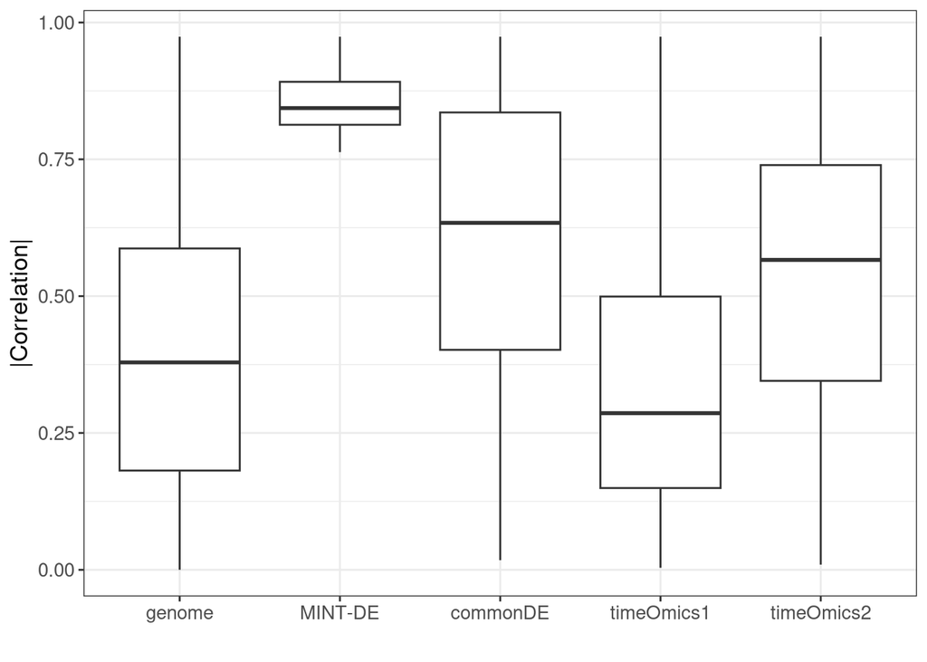

```r
cor_df = rbind(data.frame('cor'=comp_cor(edgington_genes[[5]]$idx),
                          'method' = 'MINT-DE'),
               data.frame('cor'=comp_cor(venn_genes[[5]]$idx),
                          'method' = 'commonDE'),
               data.frame('cor'=comp_cor(1:nrow(common)),
                          'method' = 'genome'),
               data.frame('cor'=comp_cor(unlist(pls_list1[[5]]),"gene_id"),
                          'method' = 'timeOmics1'),
               data.frame('cor'=comp_cor(unlist(pls_list2[[5]]),"protein_index"),
                          'method' = 'timeOmics2'))
cor_df$type = 'cor'
ggplot(data=cor_df)+
  geom_boxplot(aes(x=method,y=abs(cor)))+
  ylab('|Correlation|')+
  xlab('')+
  theme_bw()+
  theme(text = element_text(size = 13))+
  scale_x_discrete(limits=c('genome','MINT-DE','commonDE','timeOmics1','timeOmics2'))
```

```r
ggsave("top200cor.png", device = "png", width=6,height=4)
```

```r
cor_df = rbind(data.frame('cor'=comp_cor(edgington_genes[[5]]$idx),
                          'method' = 'MINT-DE'),
               data.frame('cor'=comp_cor(venn_genes[[5]]$idx),
                          'method' = 'commonDE'),
               data.frame('cor'=comp_cor(1:nrow(common)),
                          'method' = 'genome'),
               data.frame('cor'=comp_cor(unlist(pls_list1[[5]]),"gene_id"),
                          'method' = 'timeOmics1'),
               data.frame('cor'=comp_cor(unlist(pls_list2[[5]]),"protein_index"),
                          'method' = 'timeOmics2'),
               data.frame('cor'=comp_cor(fisher_genes[[5]]$idx),
                          'method' = 'Fisher'))
```

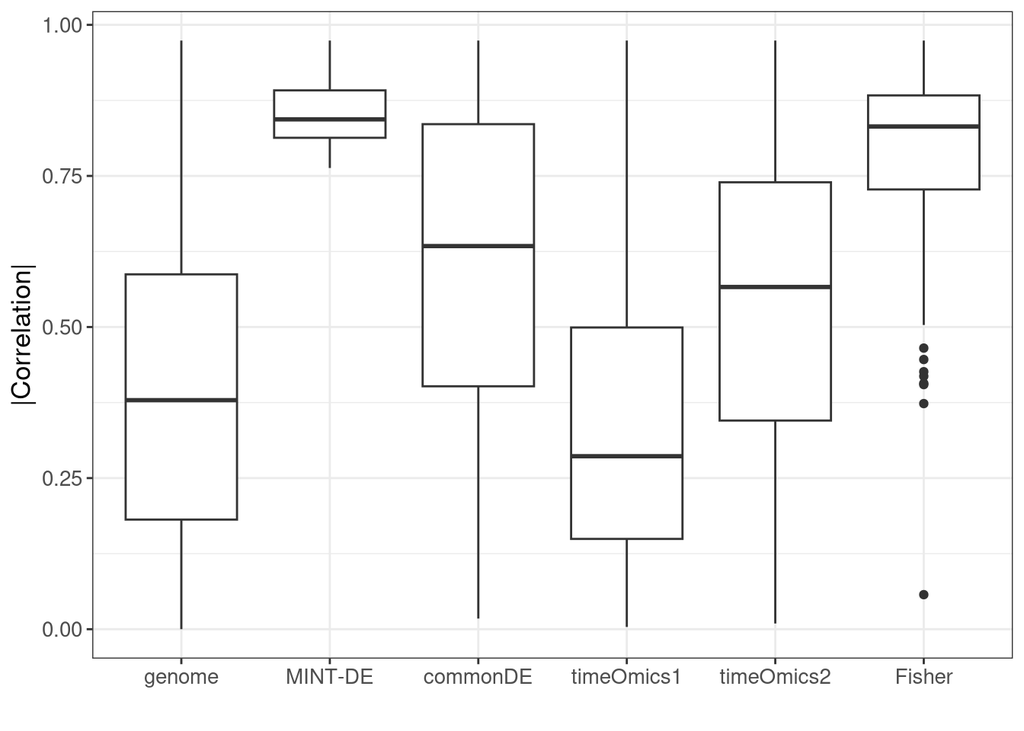

```r
cor_df$type = 'cor'
ggplot(data=cor_df)+
  geom_boxplot(aes(x=method,y=abs(cor)))+
  ylab('|Correlation|')+
  xlab('')+
  theme_bw()+
  theme(text = element_text(size = 13))+
  scale_x_discrete(limits=c('genome','MINT-DE','commonDE','timeOmics1','timeOmics2','Fisher'))
```

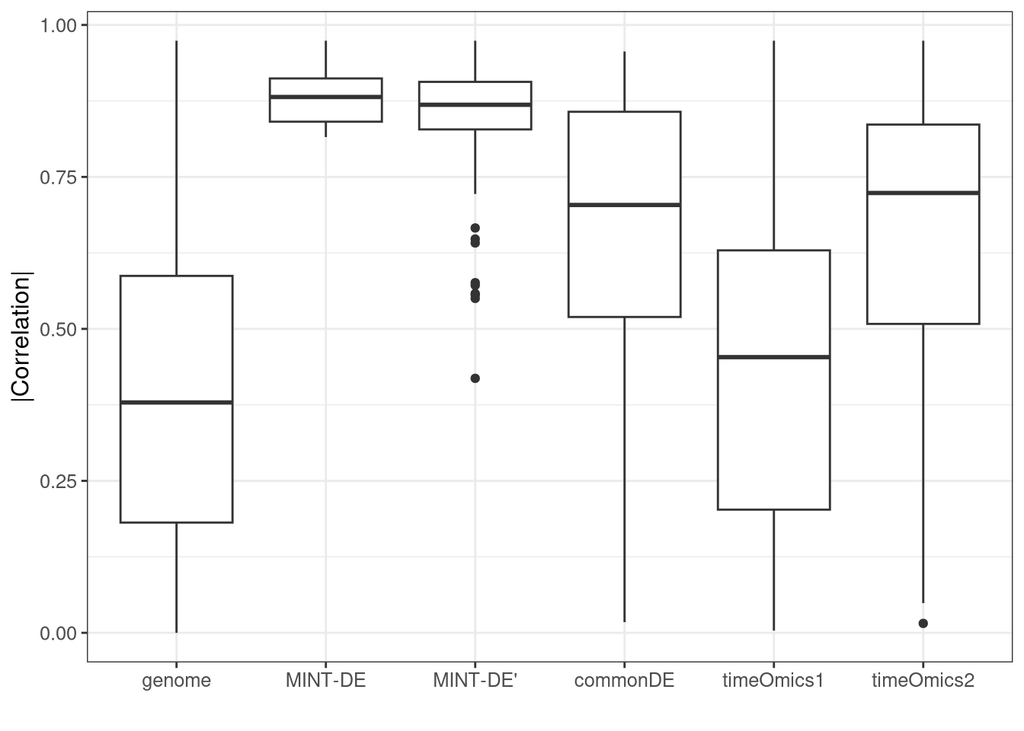

```r
cor_df2 = rbind(data.frame('cor'=comp_cor(edgington_genes[[4]]$idx),
                          'method' = 'MINT-DE'),
               data.frame('cor'=comp_cor(venn_genes[[4]]$idx),
                          'method' = 'commonDE'),
               data.frame('cor'=comp_cor(1:nrow(common)),
                          'method' = 'genome'),
               data.frame('cor'=comp_cor(unlist(pls_list1[[4]]),"gene_id"),
                          'method' = 'timeOmics1'),
               data.frame('cor'=comp_cor(unlist(pls_list2[[4]]),"protein_index"),
                          'method' = 'timeOmics2'),
               data.frame('cor'=comp_cor(fisher_genes[[4]]$idx),
                          'method' = "MINT-DE'"))
cor_df2$type = 'cor'
ggplot(data=cor_df2)+
  geom_boxplot(aes(x=method,y=abs(cor)))+
  ylab('|Correlation|')+
  xlab('')+
  theme_bw()+
  theme(text = element_text(size = 12))+
  scale_x_discrete(limits=c('genome','MINT-DE',"MINT-DE'",'commonDE','timeOmics1','timeOmics2'))
```

```r
ggsave("top100cor.png", device = "png", width=6,height=4)
```

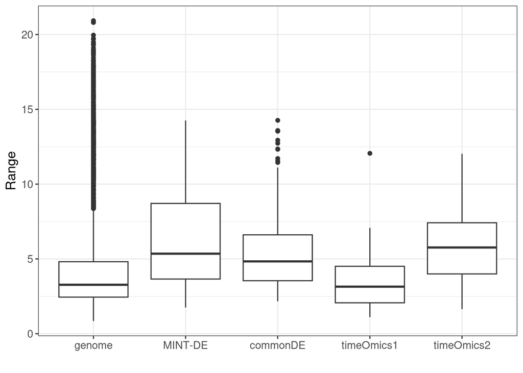

```r
range_venn = comp_range(rna_lfc[venn_genes[[5]]$gene_id,])
range_edgington = comp_range(rna_lfc[edgington_genes[[5]]$gene_id,])
range_spls1 = comp_range(rna_lfc[unlist(pls_list1[[5]]),])
range_spls2 = comp_range(as.matrix(pro_lfc[unlist(pls_list2[[5]]),unlist(rep_idx)]))
range_all = comp_range(as.matrix(common%>%dplyr::select('00h_1':'20h_4')))
range_df = rbind(data_frame(range=range_spls1,
                            method='timeOmics1'),
                 data_frame(range=range_spls2,
                            method='timeOmics2'),
                 data_frame(range=range_edgington,
                            method='MINT-DE'),
                 data_frame(range=range_venn,
                            method='commonDE'),
                 data_frame(range=range_all,
                            method='genome'))
range_plot = ggplot(data=range_df)+
  geom_boxplot(aes(x=method,y=range))+
  xlab('')+
  ylab('Range')+
  theme_bw()+
  theme(text = element_text(size = 13))+
  scale_x_discrete(limits=c('genome','MINT-DE','commonDE','timeOmics1','timeOmics2'))
range_plot
```

```r
ggsave("top200range.png", device = "png", width=6,height=4)
```

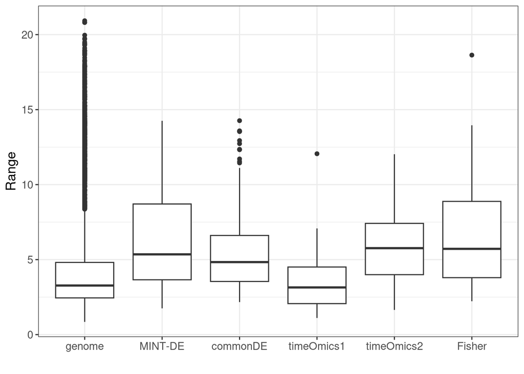

```r
range_fisher = comp_range(rna_lfc[fisher_genes[[5]]$gene_id,])
range_all = comp_range(as.matrix(common%>%dplyr::select('00h_1':'20h_4')))
range_df = rbind(data_frame(range=range_spls1,
                            method='timeOmics1'),
                 data_frame(range=range_spls2,
                            method='timeOmics2'),
                 data_frame(range=range_edgington,
                            method='MINT-DE'),
                 data_frame(range=range_venn,
                            method='commonDE'),
                 data_frame(range=range_all,
                            method='genome'),
                 data_frame(range=range_fisher,
                            method='Fisher'))
range_plot = ggplot(data=range_df)+
  geom_boxplot(aes(x=method,y=range))+
  xlab('')+
  ylab('Range')+
  theme_bw()+
  theme(text = element_text(size = 13))+
  scale_x_discrete(limits=c('genome','MINT-DE','commonDE','timeOmics1','timeOmics2','Fisher'))
range_plot
```

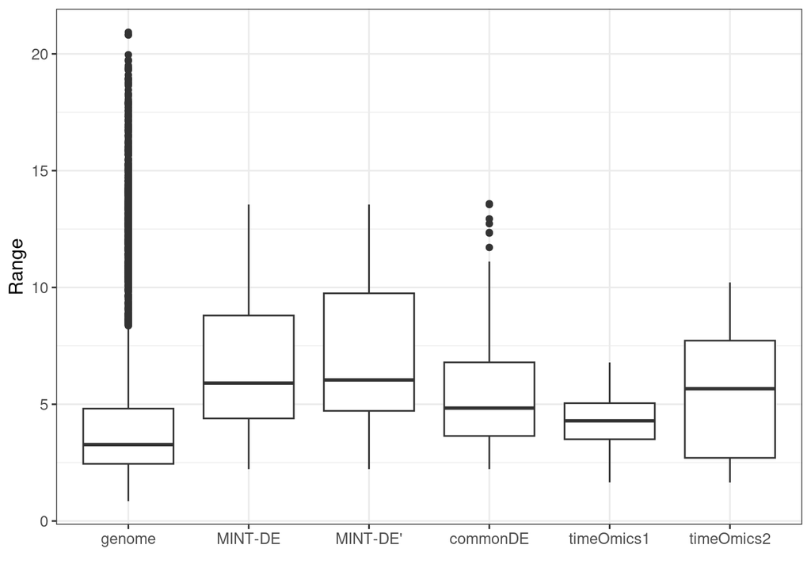

```r
range_fisher = comp_range(rna_lfc[fisher_genes[[4]]$gene_id,])
range_venn = comp_range(rna_lfc[venn_genes[[4]]$gene_id,])
range_edgington = comp_range(rna_lfc[edgington_genes[[4]]$gene_id,])
range_spls1 = comp_range(rna_lfc[unlist(pls_list1[[4]]),])
range_spls2 = comp_range(as.matrix(pro_lfc[unlist(pls_list2[[4]]),unlist(rep_idx)]))
range_all = comp_range(as.matrix(common%>%dplyr::select('00h_1':'20h_4')))
range_df = rbind(data_frame(range=range_spls1,
                            method='timeOmics1'),
                 data_frame(range=range_spls2,
                            method='timeOmics2'),
                 data_frame(range=range_edgington,
                            method='MINT-DE'),
                 data_frame(range=range_fisher,
                            method="MINT-DE'"),
                 data_frame(range=range_venn,
                            method='commonDE'),
                 data_frame(range=range_all,
                            method='genome'))
range_plot = ggplot(data=range_df)+
  geom_boxplot(aes(x=method,y=range))+
  xlab('')+
  ylab('Range')+
  theme_bw()+
  theme(text = element_text(size = 12))+
  scale_x_discrete(limits=c('genome','MINT-DE',"MINT-DE'",'commonDE','timeOmics1','timeOmics2'))
range_plot
```

```r
ggsave("top100range.png", device = "png", width=6,height=4)
```

Uncomment to save the results.

```r
write.csv(venn_genes[[5]]$gene_id,
          'eda/VennGeneList200.csv',
          row.names=F)
write.csv(edgington_genes[[5]]$gene_id,
          'eda/EdgingtonGeneList200.csv',
          row.names=F)
write.csv(unlist(pls_list1[[5]]),
          'eda/plsGeneList200_filtered.csv',
          row.names=F)
write.csv(rownames(rna_lfc),
          'eda/backgroundGeneList.csv',
          row.names=F)
write.csv(unlist(pls_list1_woFilter[[5]]),
          'eda/plsGeneList200_woFilter.csv',
          row.names=F)
```

To further illustrate the difference between the selection based Edgington’s method and that based on *timeOmics*, we fit a spline with 5 degrees of freedom with the mRNA level LFC of the selected genes. We plot the $p$-values of the fitted model vs. average LFC. This reproduce Figure 3d. The selection based on *timeOmics* are concentrated around the y-axis, since it can not specifically choose those genes with large LFC. On the contrary, our method tends to choose genes more scattered away from the y-axis, which implies those genes have larger LFC.

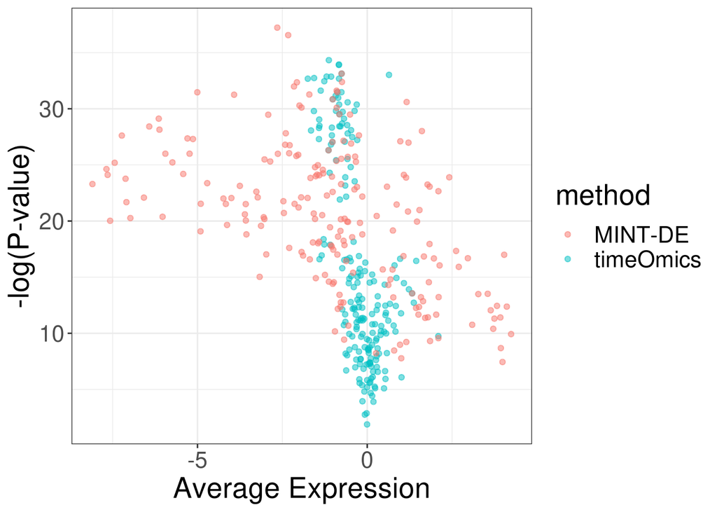

```r
library(splines)
X <- ns(rep(hours,each=4),df=5)
spDesign <- model.matrix(~X)
fit <- lmFit(rna_lfc, spDesign)
fit <- eBayes(fit)
iii=5
selected_sites = rbind(data.frame(coef=topTable(fit[unlist(pls_list1[[iii]]),], coef=2:6,
                                                length(unlist(pls_list1[[iii]])))$AveExpr,
                                  p.value=topTable(fit[unlist(pls_list1[[iii]]),], coef=2:6,
                                                   length(unlist(pls_list1[[iii]])))$P.Value,
                                  method='timeOmics'),
                       data.frame(coef=topTable(fit[edgington_genes[[iii]]$gene_id,], coef=2:6,
                                                length(edgington_genes[[iii]]$gene_id))$AveExpr,
                                  p.value=topTable(fit[edgington_genes[[iii]]$gene_id,], coef=2:6,
                                                   length(edgington_genes[[iii]]$gene_id))$P.Value,
                                  method='MINT-DE'))
# all_sites = data.frame(coef=topTable(fit, coef=2:6,
#                                      number=nrow(fit))$AveExpr,
#                        p.value=topTable(fit, coef=2:6,
#                                         number=nrow(fit))$P.Value,
#                        method='all')
ggplot()+
  geom_point(data=selected_sites,
             aes(x=coef,
                 y=-log10(p.value),
                 colour = method),
                 alpha=0.5)+
  xlab('Average Expression')+
  ylab('-log(P-value)')+
  theme_bw()+
  theme(text = element_text(size = 20))
```

```r
ggsave("VolcanoPlot.png", device = "png", width=12,height=8)
```

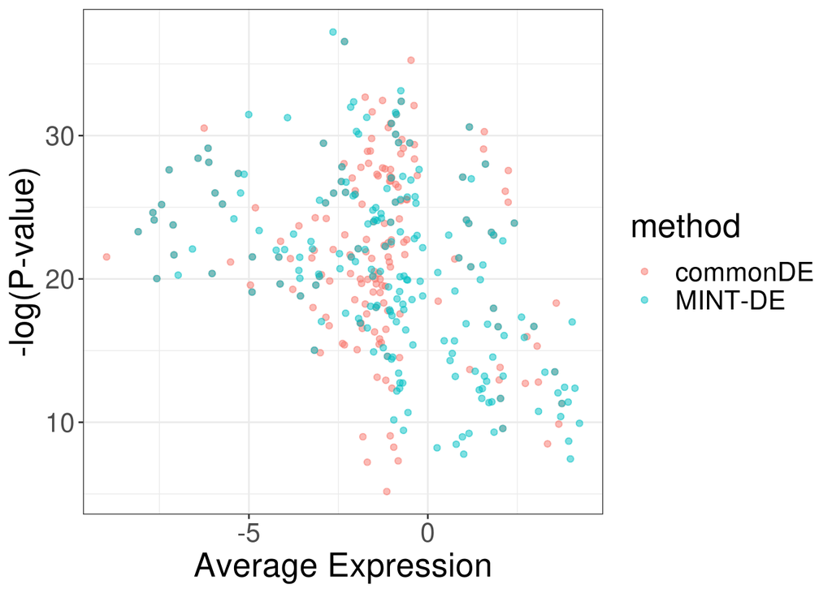

```r
iii = 5
selected_sites = rbind(data.frame(coef=topTable(fit[venn_genes[[iii]]$gene_id,], coef=2:6,
                                                length(venn_genes[[iii]]$gene_id))$AveExpr,
                                  p.value=topTable(fit[venn_genes[[iii]]$gene_id,], coef=2:6,
                                                   length(venn_genes[[iii]]$gene_id))$P.Value,
                                  method='commonDE'),
                       data.frame(coef=topTable(fit[edgington_genes[[iii]]$gene_id,], coef=2:6,
                                                length(edgington_genes[[iii]]$gene_id))$AveExpr,
                                  p.value=topTable(fit[edgington_genes[[iii]]$gene_id,], coef=2:6,
                                                   length(edgington_genes[[iii]]$gene_id))$P.Value,
                                  method='MINT-DE'))
# all_sites = data.frame(coef=topTable(fit, coef=2:6,
#                                      number=nrow(fit))$AveExpr,
#                        p.value=topTable(fit, coef=2:6,
#                                         number=nrow(fit))$P.Value,
#                        method='all')
ggplot()+
  geom_point(data=selected_sites,
             aes(x=coef,
                 y=-log10(p.value),
                 colour = method),
                 alpha=0.5)+
  xlab('Average Expression')+
  ylab('-log(P-value)')+
  theme_bw()+
  theme(text = element_text(size = 20))
```

[output not shown]

[figure not shown]

```r
ggsave("VolcanoPlot_supp.png", device = "png", width=12,height=8)
```

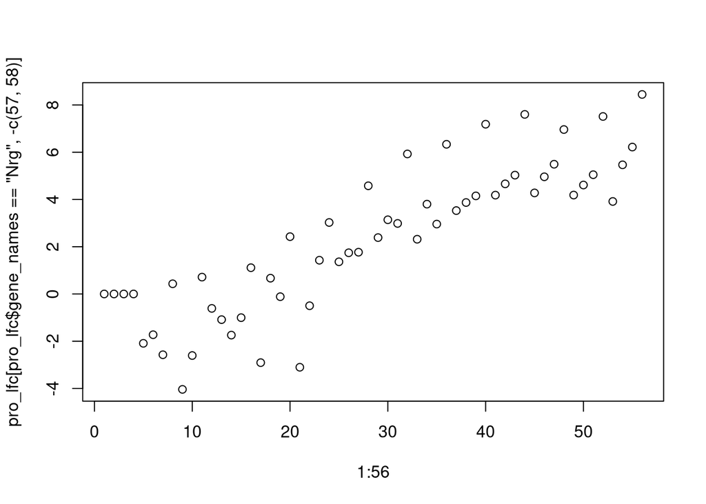

```r
plot(1:56,pro_lfc[pro_lfc$gene_names=='Nrg',-c(57,58)])
```

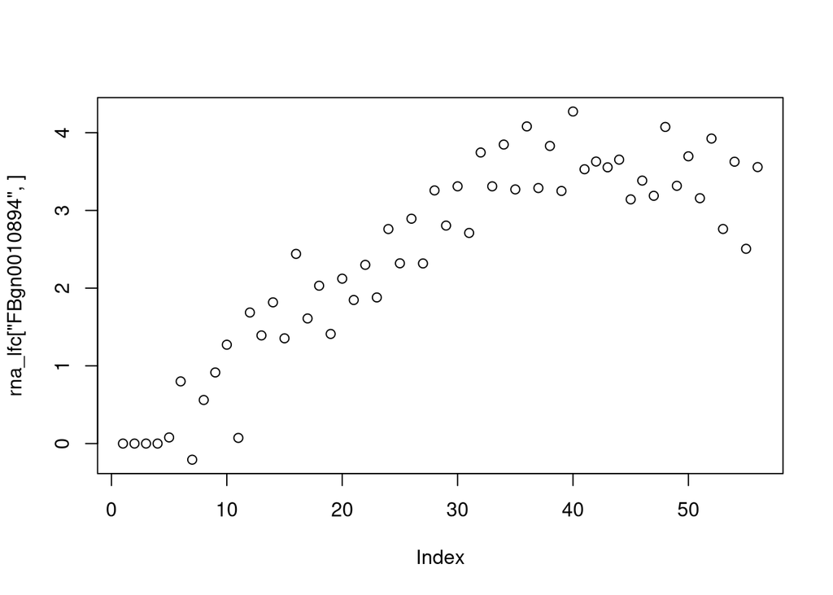

```r
plot(rna_lfc['FBgn0010894',])
```

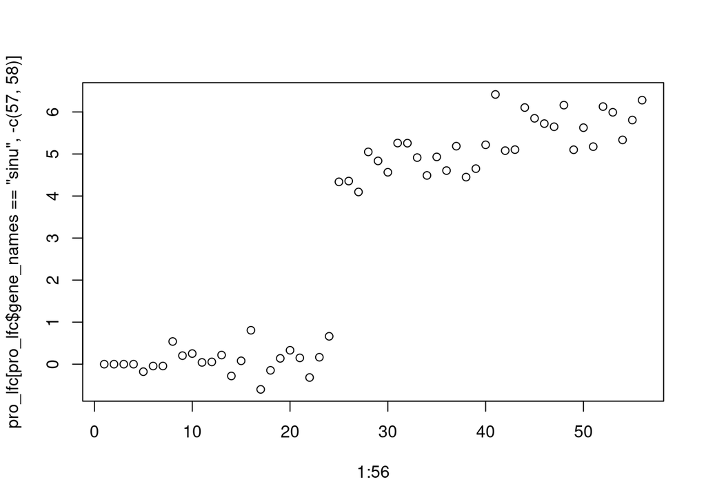

```r
plot(1:56,pro_lfc[pro_lfc$gene_names=='sinu',-c(57,58)])
```

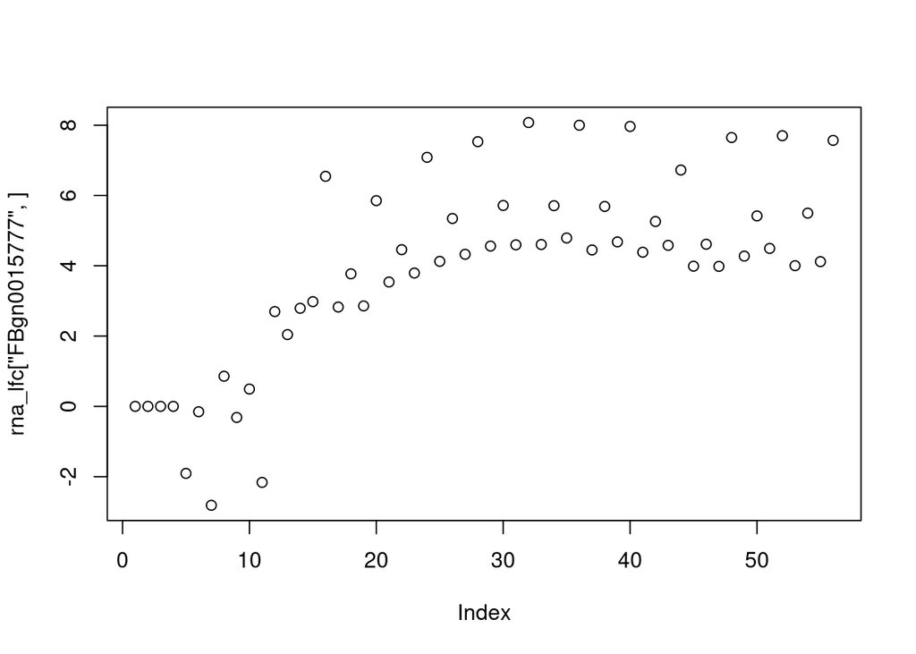

```r
plot(rna_lfc['FBgn0015777',])
```

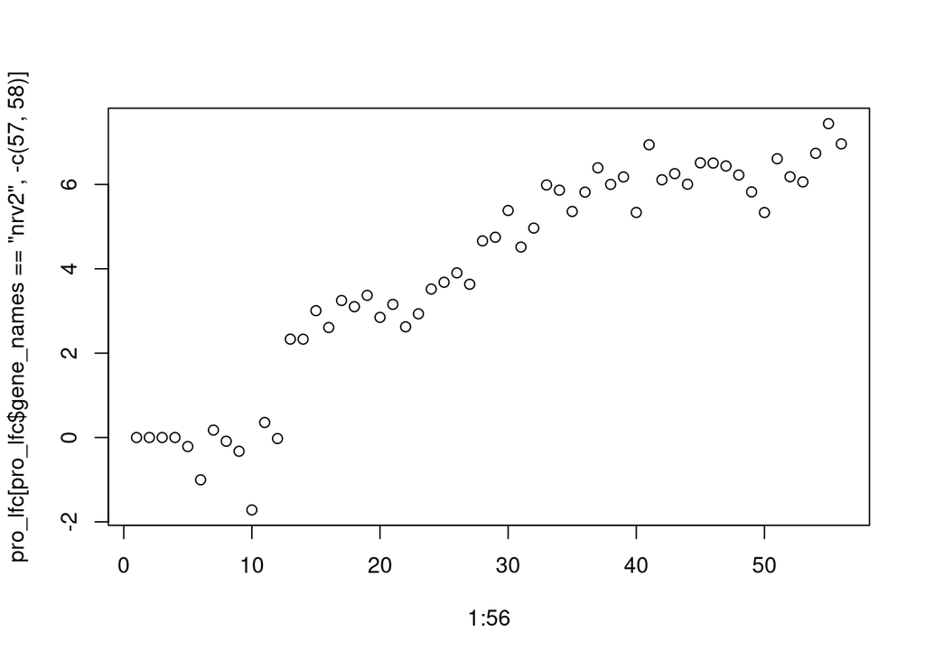

```r
plot(1:56,pro_lfc[pro_lfc$gene_names=='nrv2',-c(57,58)])
```

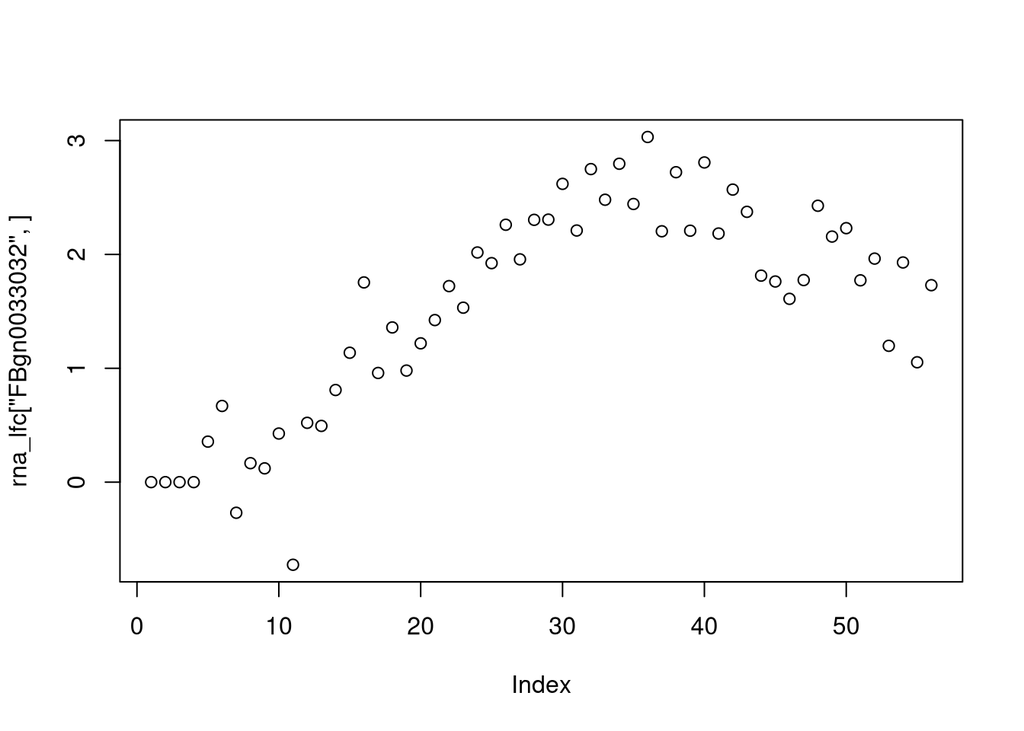

```r
plot(rna_lfc['FBgn0033032',])
```

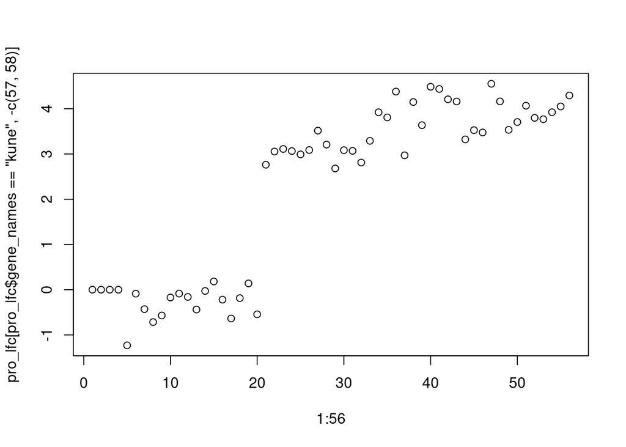

```r
plot(1:56,pro_lfc[pro_lfc$gene_names=='kune',-c(57,58)])
```

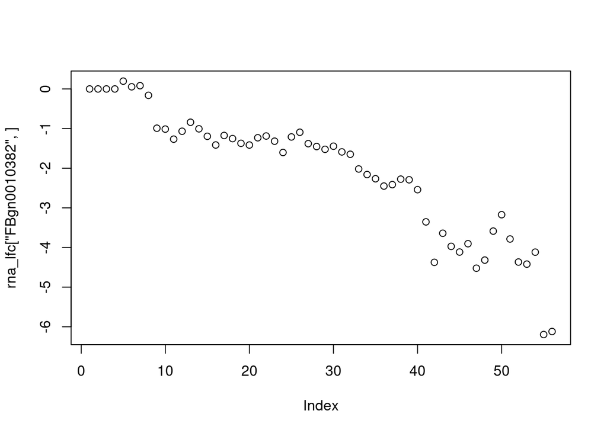

```r
plot(rna_lfc['FBgn0010382',])
```

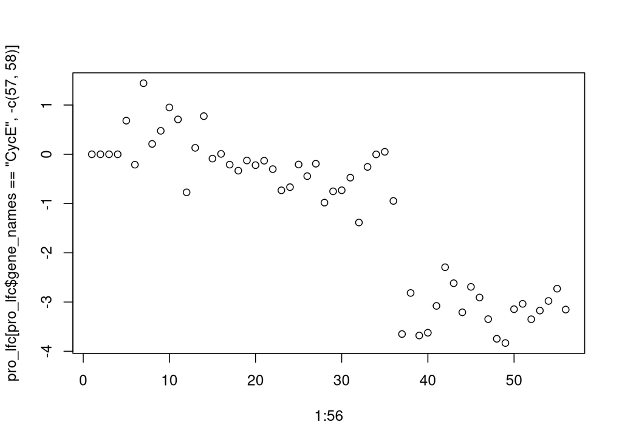

```r
plot(1:56,pro_lfc[pro_lfc$gene_names=='CycE',-c(57,58)])
```

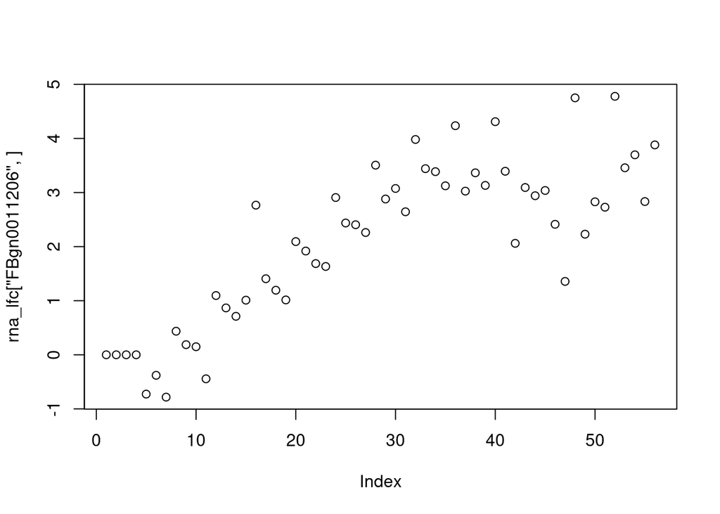

```r
plot(rna_lfc['FBgn0011206',])
```

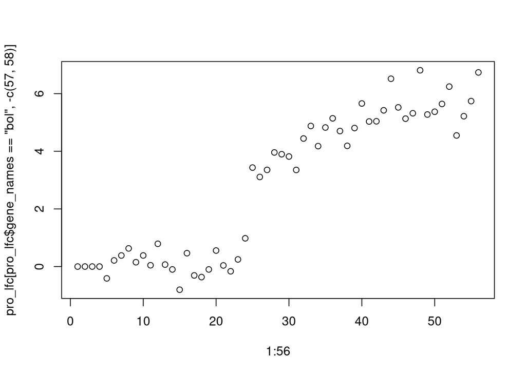

```r
plot(1:56,pro_lfc[pro_lfc$gene_names=='bol',-c(57,58)])
```

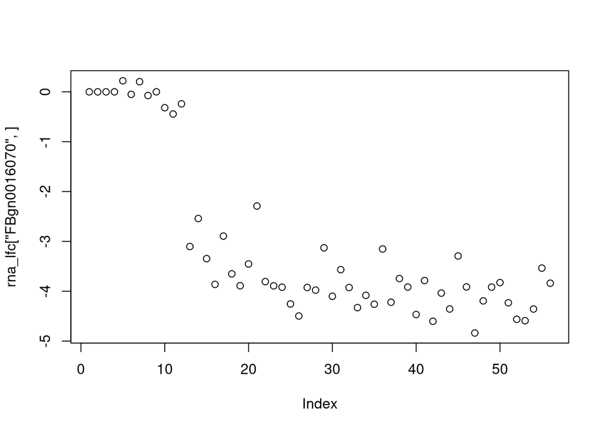

```r
plot(rna_lfc['FBgn0016070',])
```

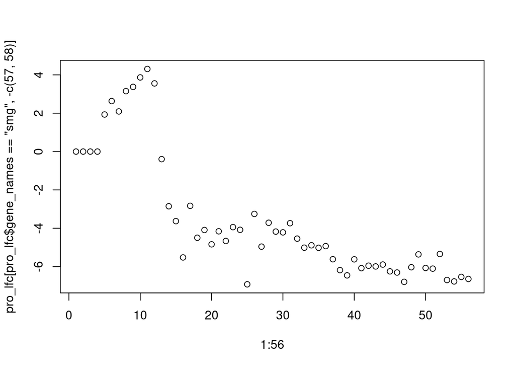

```r
plot(1:56,pro_lfc[pro_lfc$gene_names=='smg',-c(57,58)])
```

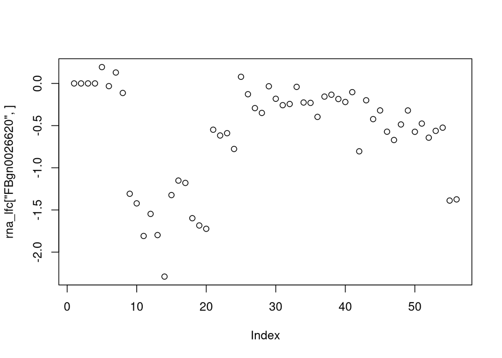

```r
plot(rna_lfc['FBgn0026620',])
```

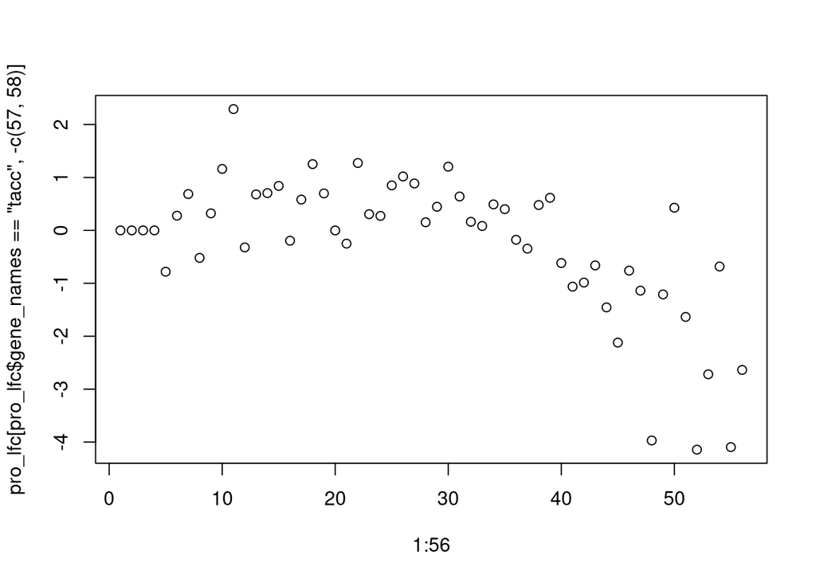

```r
plot(1:56,pro_lfc[pro_lfc$gene_names=='tacc',-c(57,58)])
```

### spindle organization

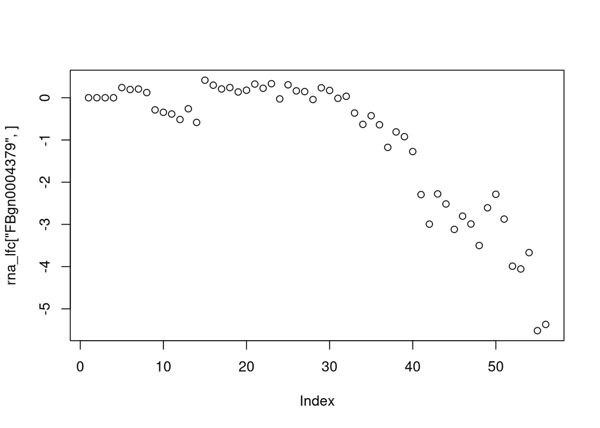

```r
plot(rna_lfc['FBgn0004379',])
```

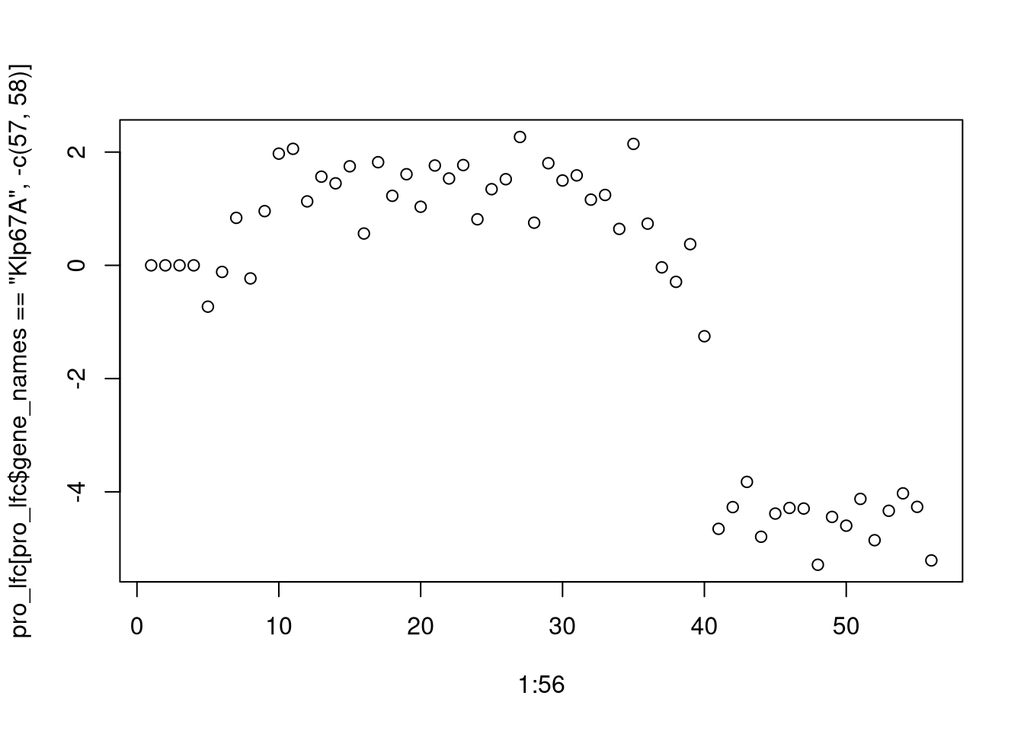

```r
plot(1:56,pro_lfc[pro_lfc$gene_names=='Klp67A',-c(57,58)])
```

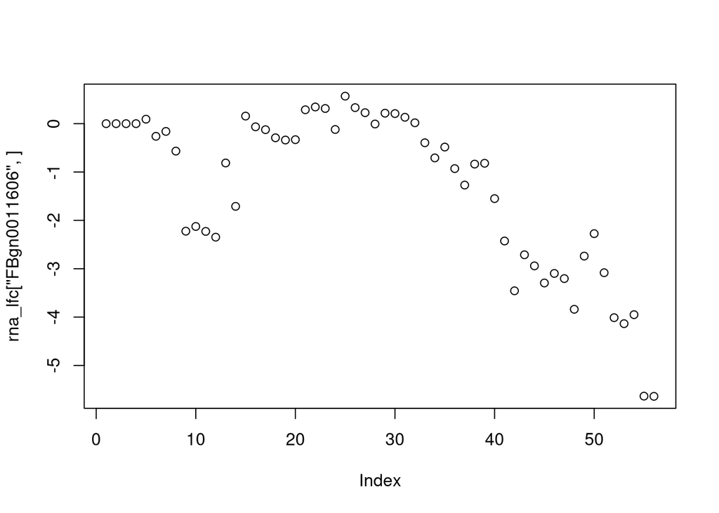

```r
plot(rna_lfc['FBgn0011606',])
```

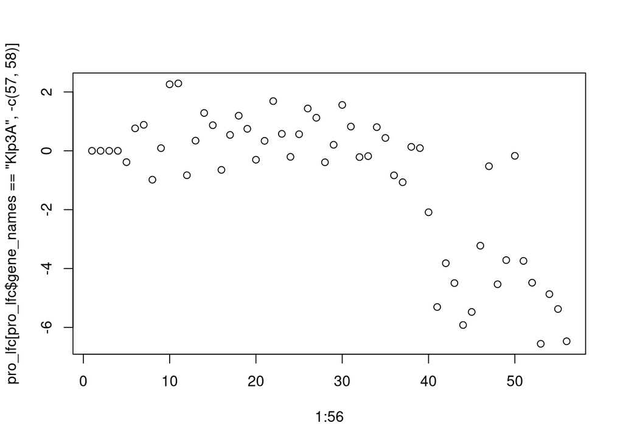

```r
plot(1:56,pro_lfc[pro_lfc$gene_names=='Klp3A',-c(57,58)])
```

### transposition

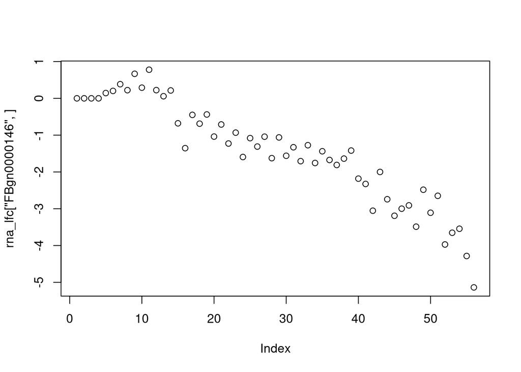

```r
plot(rna_lfc['FBgn0000146',])
```

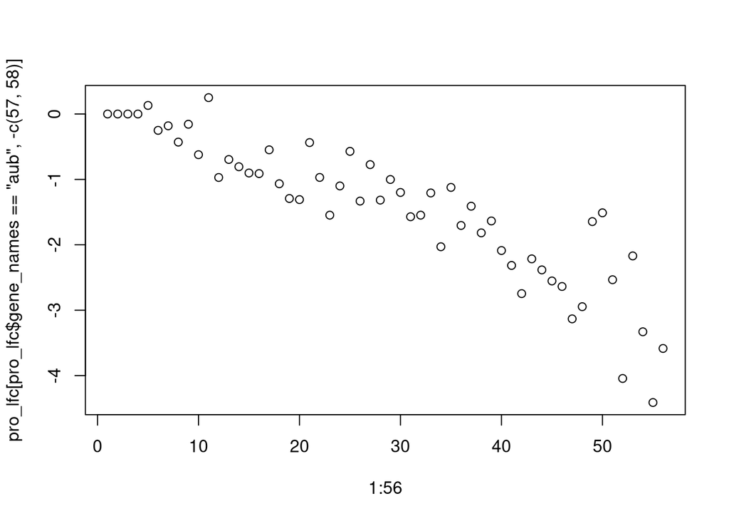

```r
plot(1:56,pro_lfc[pro_lfc$gene_names=='aub',-c(57,58)])
```

### visual behavior

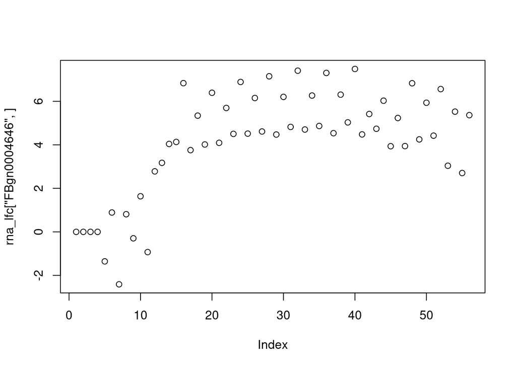

```r
plot(rna_lfc['FBgn0004646',])
```

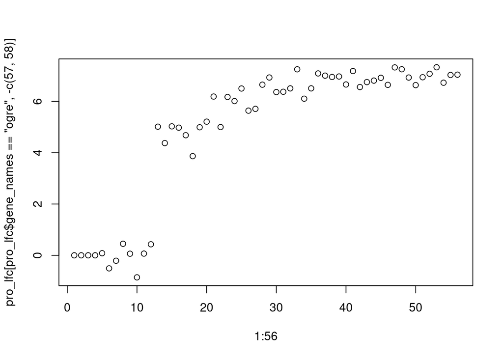

```r
plot(1:56,pro_lfc[pro_lfc$gene_names=='ogre',-c(57,58)])
```

# References

Becker, Kolja, Alina Bluhm, Nuria Casas-Vila, Nadja Dinges, Mario Dejung, Sergi Sayols, Clemens Kreutz, Jean-Yves Roignant, Falk Butter, and Stefan Legewie. 2018. “Quantifying Post-Transcriptional Regulation in the Development of Drosophila Melanogaster.” *Nature Communications* 9 (1): 4970.

Bodein, Antoine, Marie-Pier Scott-Boyer, Olivier Perin, Kim-Anh Lê Cao, and Arnaud Droit. 2022. “timeOmics: An r Package for Longitudinal Multi-Omics Data Integration.” *Bioinformatics* 38 (2): 577–79.

Edgington, Eugene S. 1972. “An Additive Method for Combining Probability Values from Independent Experiments.” *The Journal of Psychology* 80 (2): 351–63.

Law, Charity W, Yunshun Chen, Wei Shi, and Gordon K Smyth. 2014. “Voom: Precision Weights Unlock Linear Model Analysis Tools for RNA-Seq Read Counts.” *Genome Biology* 15 (2): 1–17.

Lê Cao, Kim-Anh, Pascal GP Martin, Christèle Robert-Granié, and Philippe Besse. 2009. “Sparse Canonical Methods for Biological Data Integration: Application to a Cross-Platform Study.” *BMC Bioinformatics* 10: 1–17.